# February 14, 2022

## Logical operators: `not`, `and`, `or`

Recall our `isprime2()` function from last week. This function returns `True` if the input is prime and `False` if the input is not prime.

```python
from math import sqrt

def isprime2(n):
    prime = True
    if n < 2:
        prime = False
    else:
        for d in range(2,int(sqrt(n) + 1)):
            if n%d == 0:
                prime = False # Set the flag to be False if it's not a prime
                break
    return prime
```

```python
isprime2(11)
```

```
True
```

The `not` operator will flip a `True` to `False` and a `False` to `True`

```python
not isprime2(11)
```

```
False
```

We've seen how to check if an element is in a list, so the `not` operator lets us check if an element is not in a list.

```python
mylist = [0,1,2,3,4,5,6,7]

print(3 in mylist)
```

```
True
```

```python
print(3 not in mylist)
```

```
False
```

```python
print(10 in mylist)
```

```
False
```

```python
print(10 not in mylist)
```

```
True
```

The `<expr1> and <expr2>` operator returns `True` if both `<expr1>` and `<expr2>` are `True`, and returns `False` otherwise.

```python
isprime2(2) and isprime2(5)
```

```
True
```

```python
isprime2(2) and isprime2(4)
```

```
False
```

```python
isprime2(6) and isprime2(4)
```

```
False
```

```python
True and False
```

```
False
```

The `<expr1> or <expr2>` operator returns `True` if either `<expr1>` or `<expr2>` are `True`, and returns `False` only if both are `False`.

```python
isprime2(2) or isprime2(5)
```

```
True
```

```python
isprime2(2) or isprime2(4)
```

```
True
```

```python
isprime2(6) or isprime2(4)
```

```
False
```

```python
for n in range(100):
    if (n%2 == 0 and n%7 == 0) or n == 5:
        print(n)
```

```
0
5
14
28
42
56
70
84
98
```

# Return to Project 1

For readability, I will rename `isprime2()` to be `isprime()`.

```python
from math import sqrt

def isprime(n):
    prime = True
    if n < 2:
        prime = False
    else:
        for d in range(2,int(sqrt(n) + 1)):
            if n%d == 0:
                prime = False # Set the flag to be False if it's not a prime
                break
    return prime
```

Last week, we defined `get_primes2()` and `primary()`. Let's similarly rename `get_primes2()` to be `get_primes()`.

```python
def get_primes(N):
    list_of_primes = []                # Initialize an empty list of primes
    for n in range(2,N+1):             # Iterate over the integers from 2 to N
        if isprime(n) == True:        # Check if the number is prime
            list_of_primes.append(n)   # If yes, add to a running list of primes
    return list_of_primes              # return <list of primes>
```

```python
def primary(n):
    prime_factorization = []
    primes = get_primes(n)

    for p in primes:
        m = n
        while (m % p) == 0:
            prime_factorization.append(p)
            m = m//p
    return prime_factorization
```

```python
primary(60)
```

```
[2, 2, 3, 5]
```

False primes: a number $p$ is a **false prime** if $$ a^p \equiv a \quad (\text{mod } p) $$ for every $0 \leq a < p$ and $p$ is not prime.

Let's create a function to test if a number satisfies the conclusion of Fermat's little theorem, that is, if $$ a^p \equiv a \quad (\text{mod } p) $$ for $0 \leq a < p$.

As an example, $p = 561$ is a false prime. That means that $$ a^{561} \equiv a \quad (\text{mod } 561) $$ or `(a**561) % 561 == a % 561` returns `True` for any `a`.

```python
help(pow)
```

```
Help on built-in function pow in module builtins:

pow(base, exp, mod=None)
    Equivalent to base**exp with 2 arguments or base**exp % mod with 3 arguments

    Some types, such as ints, are able to use a more efficient algorithm when
    invoked using the three argument form.
```

```python
a = 100
p = 561
pow(a,p,p) == a % p
```

```
True
```

# More about lists in Python

```python
states = ['AK','NY','MI','IL','TX']
```

```python
print(states[0])
```

```
AK
```

**Reminder**: List indexing starts with 0.

We can change a particular element in a list:

```python
print(states)
states[2] = 'CA'
print(states)
```

```
['AK', 'NY', 'MI', 'IL', 'TX']
['AK', 'NY', 'CA', 'IL', 'TX']
```

We can insert an element into a list using the `.insert()` method:

```python
help(states.insert)
```

```
Help on built-in function insert:

insert(index, object, /) method of builtins.list instance
    Insert object before index.
```

Let's add `'OH'` to our list in the second position (index `1`).

```python
states.insert(1,'OH')

print(states)
```

```
['AK', 'OH', 'NY', 'CA', 'IL', 'TX']
```

We can have lists of lists:

```python
nested = [ [1,2], [3,4,5] ]
```

```python
nested[0]
```

```
[1, 2]
```

```python
nested[1]
```

```
[3, 4, 5]
```

We can access elements inside the inner lists using `[]` again:

```python
nested[0][1]
```

```
2
```

```python
nested[1][-1]
```

```
5
```

```python
nested[1][2] = 'hello'

print(nested)
```

```
[[1, 2], [3, 4, 'hello']]
```

## List slicing

List slicing can be used to generate a sublist of a list. We use the syntax `mylist[m:n]` to access the elements whose indices are greater than or equal to `m` and less than `n`. **Note**: this does not include the index `n`.

```python
letters = ['a','b','c','d','e','f','g','h']
```

```python
letters[1:5]
```

```
['b', 'c', 'd', 'e']
```

Other syntax: We can use `mylist[m:]` to access elements whose index is greater than or equal to `m`.

```python
letters[2:]
```

```
['c', 'd', 'e', 'f', 'g', 'h']
```

We can use `mylist[:n]` to access elements whose index is less than `n`.

```python
letters[:5]
```

```
['a', 'b', 'c', 'd', 'e']
```

We can combine this with negative indices:

```python
letters[1:-2]
```

```
['b', 'c', 'd', 'e', 'f']
```

We can use `mylist[m:n:k]` to access the elements `mylist[m]`, `mylist[m+k]`, `mylist[m+2*k]`... until we reach the `n`th index.

```python
letters[::2]
```

```
['a', 'c', 'e', 'g']
```

```python
letters[1::2]
```

```
['b', 'd', 'f', 'h']
```

```python
letters[1:-1:2]
```

```
['b', 'd', 'f']
```

```python
letters[::3]
```

```
['a', 'd', 'g']
```

We can use slicing to change several elements in a list at once.

```python
a = [1,2,3,4,5,6,7,8]
```

```python
a[:3] = [100,100,100]
```

```python
print(a)
```

```
[100, 100, 100, 4, 5, 6, 7, 8]
```

We've seen how lists and strings can be treated similarly. We can use slicing with strings as well.

```python
s = 'abcdefghijklmnopqrstuvwxyz'
```

```python
s[1]
```

```
'b'
```

```python
s[1:-1:5]
```

```
'bglqv'
```

```python
filename = 'week2_notebook.ipynb'
```

```python
filetype = filename[-5:]
print(filetype)
```

```
ipynb
```

# February 16, 2022

## Mutable vs immutable lists

[(see course webpage)](https://jllottes.github.io/PT/PT-mutable_vs_immutable/PT-mutable_vs_immutable.html)

```python
a = [1,2,3]
print(a)
```

```
[1, 2, 3]
```

```python
b = a
print(b)
```

```
[1, 2, 3]
```

What happens if we modify `b`?

```python
b[0] = 100
print(b)
```

```
[100, 2, 3]
```

```python
print(a)
```

```
[100, 2, 3]
```

Notice: the change in `b` is propogated back to `a`.

By comparison:

```python
a = 1
b = a
```

```python
print(a)
print(b)
```

```
1
1
```

```python
b = 4
```

```python
print(a)
print(b)
```

```
1
4
```

This time, modifying `b` did not modify `a`.

Let's explore this a little more. We've seen how to use `==` to check for equality between objects. We can also use the `id()` function to check if two variables are the **same object**.

```python
a = 1
b = 1

print(a==b)
```

```
True
```

```python
help(id)
```

```
Help on built-in function id in module builtins:

id(obj, /)
    Return the identity of an object.

    This is guaranteed to be unique among simultaneously existing objects.
    (CPython uses the object's memory address.)
```

```python
id(a)
```

```
140708010665776
```

```python
id(b)
```

```
140708010665776
```

```python
id(1)
```

```
140708010665776
```

```python
id(a) == id(b)
```

```
True
```

```python
b = 2
print(id(b))
```

```
140708010665808
```

```python
print(id(b) == id(a))
```

```
False
```

```python
a = [1,2,3]
b = a
```

```python
print(id(a)==id(b))
```

```
True
```

```python
b[0] = 100
```

```python
print(id(a)==id(b))
```

```
True
```

```python
c = [100,2,3]
```

```python
print(a)
print(c)
print(a==c)
print(id(a)==id(c))
```

```
[100, 2, 3]
[100, 2, 3]
True
False
```

Even though the contents the lists are the same, they have different IDs. If we make changes to `c`, they will not propogate back to `a` since they have different IDs.

```python
c[0] = 1

print(a)
print(c)
```

```
[100, 2, 3]
[1, 2, 3]
```

We can get around this issue of sharing IDs by forcing a new list to be instantiated.

```python
a = [1,2,3]
b = list(a)

print(id(a)==id(b))
```

```
False
```

```python
b[0] = 100

print(a)
print(b)
```

```
[1, 2, 3]
[100, 2, 3]
```

## More about functions.

[(see course webpage)](https://jllottes.github.io/PT/PT-functions.html)

```python
def my_func(x,y,z):
    print('x = {:}'.format(x))
    print('y = {:}'.format(y))
    print('z = {:}'.format(z))
    return
```

```python
my_func(1,2,3)
```

```
x = 1
y = 2
z = 3
```

In this function, `x`,`y`, and `z` are **positional arguments**. Each of them must be supplied by the user in the correct order.

```python
my_func(2,3,1)
```

```
x = 2
y = 3
z = 1
```

In Python, we can also supply **keyword arguments.** That is, we can manually specify which inputs go to which variables.

```python
my_func(y=2,z=3,x=1)
```

```
x = 1
y = 2
z = 3
```

We use keyword arguments to be able to call a function with our inputs in different orders.

When defining functions, we can also set **default arguments**.

```python
def my_func2(x=1,y=2,z=3):
    print('x = {:}'.format(x))
    print('y = {:}'.format(y))
    print('z = {:}'.format(z))
    return
```

```python
my_func2()
```

```
x = 1
y = 2
z = 3
```

```python
my_func2(-5)
```

```
x = -5
y = 2
z = 3
```

```python
my_func2(-5,7)
```

```
x = -5
y = 7
z = 3
```

```python
my_func2(-5,7,9)
```

```
x = -5
y = 7
z = 9
```

We can combine default arguments with keyword arguments:

```python
my_func2(z=9)
```

```
x = 1
y = 2
z = 9
```

We can combine positional arguments with default arguments.

```python
def my_func3(x,y,z=3):
    print('x = {:}'.format(x))
    print('y = {:}'.format(y))
    print('z = {:}'.format(z))
    return
```

```python
my_func3(5,6)
```

```
x = 5
y = 6
z = 3
```

Timer function.

We've used the time module to time Python code. There are other tools in this module.

```python
import time
```

```python
help(time.sleep)
```

```
Help on built-in function sleep in module time:

sleep(...)
    sleep(seconds)

    Delay execution for a given number of seconds.  The argument may be
    a floating point number for subsecond precision.
```

We'll make a function `timer` that prints a countdown from a specified number.

```python
for i in range(0,5,2):
    print(i)
```

```
0
2
4
```

```python
for i in range(5,0,-1):
    print(i)
```

```
5
4
3
2
1
```

```python
def timer(n,msg='time up!',delay=1):
    from time import sleep

    for i in range(n,0,-1):
        print(i)
        sleep(delay)
    print(msg)
```

```python
timer(5,delay=.5,msg='beep!')
```

```
5
4
3
2
1
beep!
```

# Sieve of Eratosthenes

**Exercise.** Write a function `get_primes(n)` that will make a list of all prime numbers less than or equal to `n` using the Sieve of Eratosthenes.

```python
def get_primes(n):
    # Make a list that has length n+1 and is set to True in every element,
    # except for the 0 and 1 elements.
    # Associate the index of the list with a number 0,1,2,3,...,n
    # Starting from the first True entry, we'll set False all entries corresponding
    # to a multiple of that number.

    # At the end, we'll have a list of True/False objects, from which we
    # can build a list of primes.

    mylist = []
    for i in range(n+1):
        mylist.append(True)
    mylist[0] = False
    mylist[1] = False

    for i in range(n+1):
        # if mylist[i] == False:
        # or
        if not mylist[i]:
            continue
        m = 2*i
        while m <= n:
            mylist[m] = False
            m = m + i
    return mylist
```

```python
mylist = get_primes(7)
```

```python
print(mylist)
```

```
[False, False, True, True, False, True, False, True]
```

We can replace this `while` loop with slicing.

```python
def get_primes(n):
    # Make a list that has length n+1 and is set to True in every element,
    # except for the 0 and 1 elements.
    # Associate the index of the list with a number 0,1,2,3,...,n
    # Starting from the first True entry, we'll set False all entries corresponding
    # to a multiple of that number.

    # At the end, we'll have a list of True/False objects, from which we
    # can build a list of primes.

    mylist = []
    for i in range(n+1):
        mylist.append(True)
    mylist[0] = False
    mylist[1] = False

    for i in range(n+1):
        if not mylist[i]:
            continue
        # mylist[2*i::i] = False
        # Issue: the object on the left is a list with some number of elements
        # The object on the right a single False boolean.
        # We fix this by generating a list of Falses that has the right size
        myslice = mylist[2*i::i]
        falselist = []
        for j in range(len(myslice)):
            falselist.append(False)
        mylist[2*i::i] = falselist
    return mylist
```

**Note**: We still need to finish the `get_primes()` function so that it returns a list of prime numbers rather than a list of `True`/`False`.

```python
print(get_primes(7))
```

```
[False, False, True, True, False, True, False, True]
```

## List comprehension

[(see course webpage)](https://jllottes.github.io/PT/PT-list_comprehensions/PT-list_comprehensions.html)

In Python, we can use **list comprehension** to easily generate lists.

Let's generate a list that contains 5 `False`s.

```python
[False,False,False,False,False]
```

```
[False, False, False, False, False]
```

```python
[ False for i in range(5) ]
```

```
[False, False, False, False, False]
```

```python
[ i for i in range(5) ]
```

```
[0, 1, 2, 3, 4]
```

```python
[ i**2 for i in range(10) if i%2 == 0]
```

```
[0, 4, 16, 36, 64]
```

```python
def get_primes(n):
    is_prime = [ True for i in range(n+1) ]
    is_prime[0] = False
    is_prime[1] = False

    for i in range(n+1):
        if not is_prime[i]:
            continue
        is_prime[2*i::i] = [ False for j in range(len(is_prime[2*i::i]))]

    primes = [ i for i in range(n+1) if is_prime[i] ]
    return primes
```

```python
get_primes(100)
```

```
[2,
 3,
 5,
 7,
 11,
 13,
 17,
 19,
 23,
 29,
 31,
 37,
 41,
 43,
 47,
 53,
 59,
 61,
 67,
 71,
 73,
 79,
 83,
 89,
 97]
```

## Plotting with matplotlib

[(see course webpage)](https://jllottes.github.io/PT/PT-matplotlib_plots/PT-matplotlib_plots.html)

```python
import matplotlib.pyplot as plt
```

```python
x = [1,2,3,4,5]
y = [i**2 for i in x]

print(x)
print(y)
```

```
[1, 2, 3, 4, 5]
[1, 4, 9, 16, 25]
```

Syntax: `plt.plot(<x-coordinates>,<y-coordinates>)`

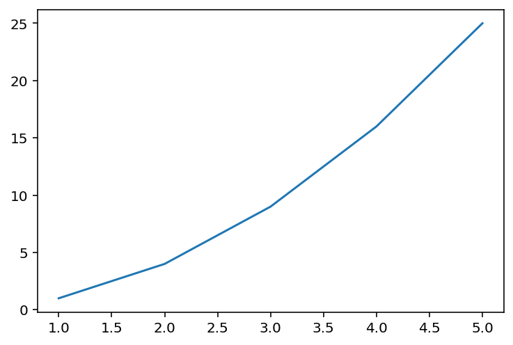

```python
plt.plot(x,y)
```

If your plot does not show within the Jupyter notebook, you can execute the following command in a separate cell to force inline plotting:

`%matplotlib inline`

We can make plots look sharper by making changes to the backend:

```python
%config InlineBackend.figure_format = 'retina'
```

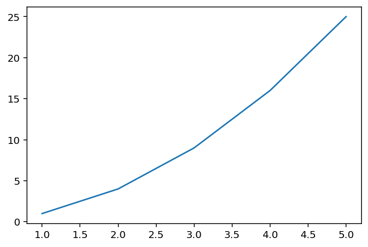

```python
plt.plot(x,y)
```

There are **MANY** possible default and keyword arguments that can be supplied to the `plot()` command.

One option is to supply a string following the $x$- and $y$-coordinates that specifies the style of the plot.

As an example, we can specify a color:

`'k'`: black

`'b'`: blue

`'r'`: red

`'y'`: yellow

`'g'`: green

`'m'`: magenta

`'c'`: cyan

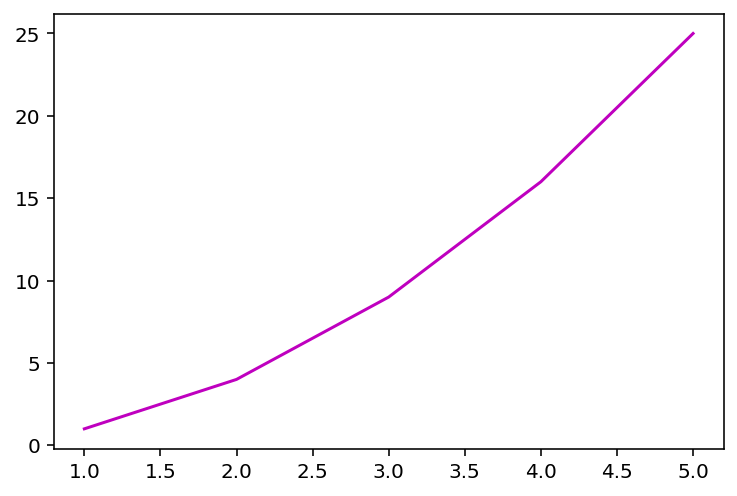

```python
plt.plot(x,y,'m')
```

We can specify a **marker** type:

`'o'`: big dot

`'.'`: small dot

`'*'`: star

...

see: [matplotlib markers](https://matplotlib.org/stable/api/markers_api.html)

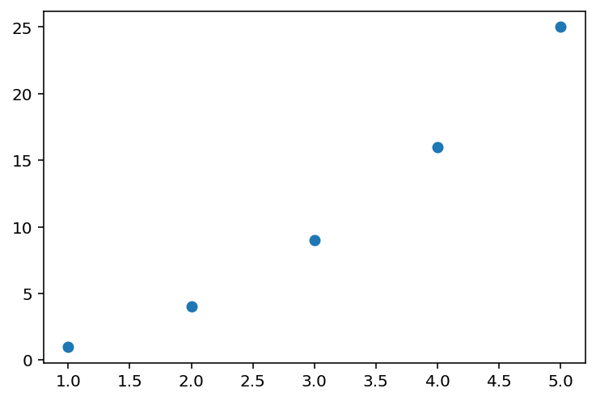

```python
plt.plot(x,y,'o')
```

We can specify line styles:

`'-'`: solid line

`'--'`: dashed line

See [matplotlib linestyles](https://matplotlib.org/stable/gallery/lines_bars_and_markers/linestyles.html)

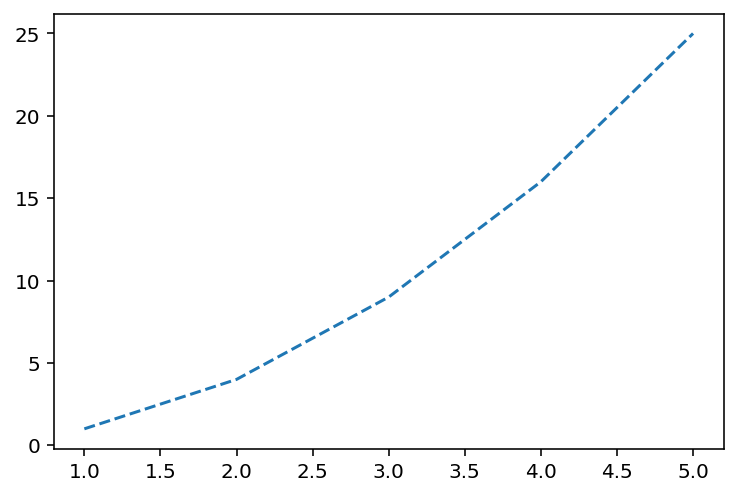

```python
plt.plot(x,y,'--')
```

We can specify styles for color, line, and marker at the same time.

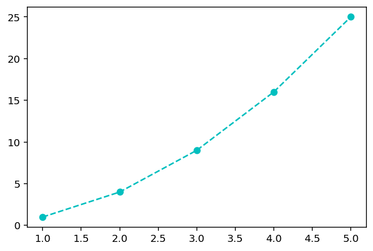

```python
plt.plot(x,y,'c--o')
```

Alternatively, we can use keyword arguments:

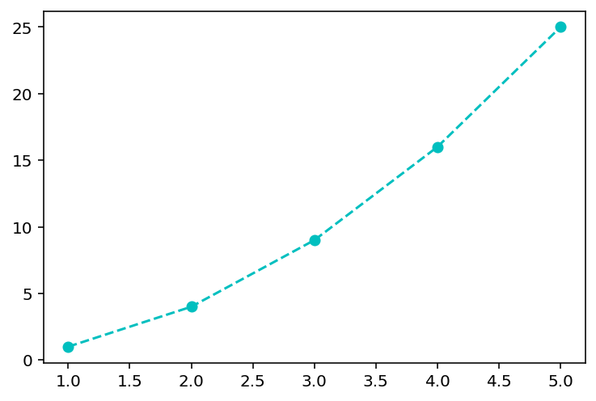

```python
plt.plot(x,y,color='c',marker='o',linestyle='--')
```

We can add $x$- and $y$- labels using the `plt.xlabel()` and `plt.ylabel()` commands. We can even use LaTeX in our labels.

We can add a title using the `plt.title()` command.

We can label a plot using the `label` keyword.

We can add a legend with the `plt.legend()` command.

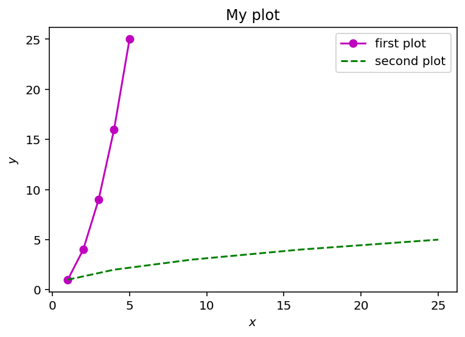

```python
plt.plot(x,y,'m-o',label='first plot')
plt.plot(y,x,'g--',label='second plot')

plt.xlabel('$x$')
plt.ylabel('$y$')

plt.title('My plot')

plt.legend()
```

If we don't manually supply a color, then `matplotlib` will cycle through a predetermined list of colors.

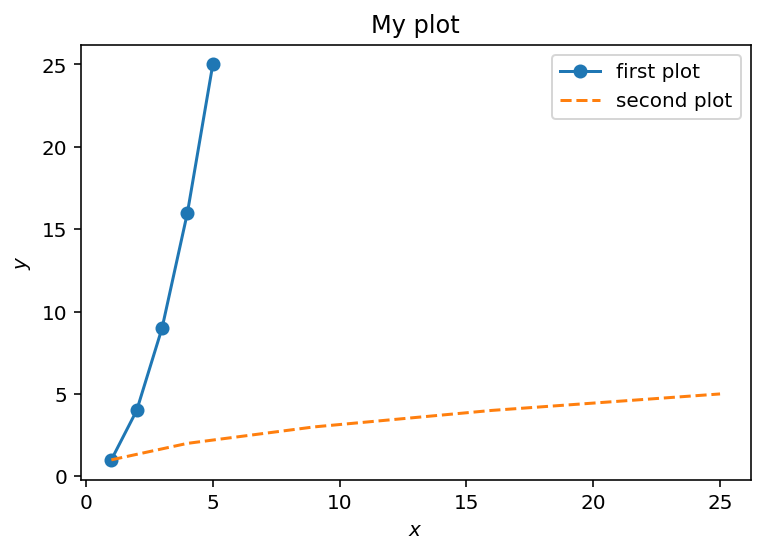

```python
plt.plot(x,y,'-o',label='first plot')
plt.plot(y,x,'--',label='second plot')

plt.xlabel('$x$')
plt.ylabel('$y$')

plt.title('My plot')

plt.legend()
```